# Smooth Bilevel Sparse Regularization

# Smooth Bilevel Sparse Regularization

Reformulate a sparse regression objective through a smooth factorization and an inner linear solve. Check the reduced gradient numerically and compare the resulting optimization trajectory with direct sparse regression methods.

## Run this tour

Run the cells in order with a Python 3 kernel. The first cell locates the companion data and toolbox and installs missing dependencies when needed. All worked examples include their implementation directly in this notebook. Random seeds make comparisons reproducible; you can change them to explore other samples.

```python
# Locate the companion toolbox locally, or fetch it for a standalone/Colab copy.
from pathlib import Path
import importlib.util
import os
import subprocess
import sys

working = Path.cwd()
candidates = [working, working / "python", working.parent / "python"]
python_dir = next((p for p in candidates if (p / "nt_toolbox").is_dir()), None)
if python_dir is None:
    checkout = working / "numerical-tours-support"
    if not checkout.exists():
        subprocess.run(
            [
                "git",
                "clone",
                "--depth",
                "1",
                "--branch",
                "master",
                "https://github.com/gpeyre/numerical-tours.git",
                str(checkout),
            ],
            check=True,
        )
    python_dir = checkout / "python"
os.chdir(python_dir)
if str(python_dir) not in sys.path:
    sys.path.insert(0, str(python_dir))
requirements = python_dir / "requirements.txt"
if any(
    importlib.util.find_spec(name) is None
    for name in [
        "numpy",
        "scipy",
        "matplotlib",
        "skimage",
        "sklearn",
        "pywt",
        "ipywidgets",
        "cvxpy",
        "skfmm",
        "autograd",
        "progressbar",
        "celer",
    ]
):
    subprocess.run(
        [sys.executable, "-m", "pip", "install", "-r", str(requirements)], check=True
    )

import numpy as np
import matplotlib.pyplot as plt

np.random.seed(0)
plt.rcParams.update(
    {
        "figure.figsize": (8, 4),
        "figure.dpi": 100,
        "axes.spines.top": False,
        "axes.spines.right": False,
        "font.size": 11,
        "image.cmap": "gray",
    }
)
%matplotlib inline
```

This tour is a tutorial reviewing the method developped in the paper:

> *[Smooth Bilevel Programming for Sparse Regularization](https://arxiv.org/abs/2106.01429)* Clarice Poon, Gabriel Peyré, 2021

We present a surprisingly simple reformulation of the Lasso as a bilevel program, which can be solved using efficient method such as L-BFGS. This gives an algorithm which is simple to implement and is in the same ballpark as state of the art approach when the regularization parameter $\lambda$ is small (it can in particular cope in a seamless way with the constraint formulation when $\lambda=0$). For large $\lambda$, and when the solution is very sparse, the method is not as good as for instance coordinate methods with safe screening/support pruning such as the [Celer](https://github.com/mathurinm/celer) solver which we warmly recommend.

```python
import numpy as np
from numpy.linalg import norm
import matplotlib.pyplot as plt
import time
import warnings
import progressbar
```

## Lasso problem

We aim at solving the Lasso problem $$ \min_x \frac{1}{2\lambda}\| A x -y \|^2 + \|x\|_1. $$ We generate here a synthetic example using a random matrix $A \in \mathbb{R}^{n \times p}$ and $y \in \mathbb{R}^p$.

```python
n = 10
p = n * 2
np.random.seed(0)
A = np.random.randn(n, p)
y = np.random.randn(n)
```

The simplest (but arguably not the fastest) algorithm to solve this problem is the iterative soft thresholding

$$ x_{k+1} = \text{Thresh}_{\tau \lambda}( y - \tau A^\top (Ax_k-y) ) $$

where the step size should satisfies $\tau < 2/\|A\|^2$, and Thresh is the soft thresholding

$$ \text{Thresh}_\sigma( x ) = \text{sign}(x) \max(|x|-\sigma,0) $$

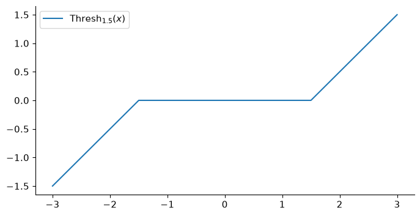

```python
def Thresh(x, sigma):
    return np.sign(x) * np.maximum(np.abs(x) - sigma, 0)


x = np.linspace(-3, 3, 1000)

plt.plot(x, Thresh(x, 1.5), label="Thresh$_{1.5}(x)$")
plt.legend();
```

The critical $\lambda$ for which the solution of the Lasso is 0 is $\|A^\top y\|_\infty$. We select the $\lambda$ as a fraction of this value.

```python
la = 0.5 * np.max(np.abs(A.T @ y))
```

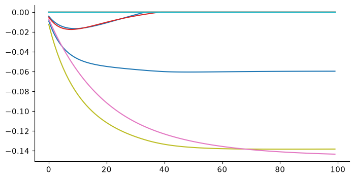

```python
tau = 1 / np.linalg.norm(A) ** 2
niter = 100
x = np.zeros(p)
x_ista = np.zeros((p, niter))
for it in range(niter):
    x = Thresh(x - tau * A.T @ (A @ x - y), tau * la)
    x_ista[:, it] = x
plt.plot(x_ista.T);
```

## Non-convex Variational Projection

The following variational formulation is pivotal for the developpement of our approach $$ \|x\|_1 = \min_{u \odot v = x} \frac{\|u\|_2^2 + \|v\|_2^2 }{2} $$ where $u \odot v = (u_i v_i)_{i=1}^p$.

Thanks to this formula, we can minimize the Lasso problem on $(u,v)$ instead of $x$ (which corresponds to an over-parameterization of the problem). The crux of the method is that instead of doing an alternative minimization over $u$ and $v$ (which is a classical method), we rather consider a bilevel formulation

$$ \min_{v} f(v) \quad \text{where} \quad f(v) = \min_{u} F(u,v) \triangleq \frac{1}{2 \lambda}\| A(u \odot v) - y \|^2 + \frac{\|u\|_2^2 + \|v\|_2^2 }{2} $$ The effect of this bilevel formulation is to make the function $f$ better conditionned (and in particular smooth) than the original Lasso functional.

For a given $v$, the optimal $u$ solving the inner problem $\min_u F(u,v)$ is unique and can be found by solving a linear system

$$ u^\star(v) = ( \text{diag}(v) A^\top A \text{diag}(v) + \lambda \text{Id}_p )^{-1} ( v \odot A^\top y ) $$

```python
def u_opt1(v):
    T = np.diag(v) @ A.T @ A @ np.diag(v) + la * np.eye(p)
    return np.linalg.solve(T, v * (A.T @ y))
```

Using [Sherman–Morrison](https://en.wikipedia.org/wiki/Sherman%E2%80%93Morrison_formula), this equivalently reads $$ u^\star(v) = v \odot A^\top ( A \text{diag}(v^2) A^\top + \lambda \text{Id}_n )^{-1} y. $$ This formula is more efficient when $p>n$ (which is the case here).

```python
def u_opt(v):
    S = A @ np.diag(v**2) @ A.T + la * np.eye(n)
    return v * (A.T @ np.linalg.solve(S, y))
```

Compare the two formula.

```python
v = np.random.randn(p)
print(f"Should be 0: {norm(u_opt1(v) - u_opt(v)):.2e}")
```

```
Should be 0: 9.63e-16
```

According to the [envelope theorem](https://en.wikipedia.org/wiki/Envelope_theorem), the function $f$ is thus differentiable and its gradient reads $$ \nabla f(v) = \nabla_v F(u^\star(v),v) = \frac{1}{\lambda} u^\star \odot A^\top ( A (u^\star \odot v) - y ) + v $$

```python
def nabla_f(v):
    u = u_opt(v)
    function = (
        1 / (2 * la) * norm(A @ (u * v) - y) ** 2 + (norm(u) ** 2 + norm(v) ** 2) / 2
    )
    gradient = u * (A.T @ (A @ (u * v) - y)) / la + v
    return function, gradient
```

Test using finite difference that the formula is correct $$ \frac{f(v+t \delta) - f(v)}{t} \approx \langle \nabla f(v), \delta \rangle $$

```python
t = 1e-6
delta = np.random.randn(p)
f, g = nabla_f(v)
f1, g1 = nabla_f(v + t * delta)
d1 = (f1 - f) / t
d2 = np.sum(delta * g)
print("Should be small: " + str((d1 - d2) / d1))
```

```
Should be small: 9.929823567512655e-06
```

We can also let scipy do the work for us using `scipy.optimize.check_grad()`:

```python
from scipy import optimize

optimize.check_grad(
    lambda v: nabla_f(v)[0], lambda v: nabla_f(v)[1], np.random.randn(p)
)
```

```
np.float64(3.2365500036403326e-07)
```

We implement a simple [gradient descent](https://en.wikipedia.org/wiki/Gradient_descent) $$ v_{k+1} = v_k - \tau \nabla f(v_k) $$ and display the evolution of $x_k = u^\star(v_k) \odot v_k$.

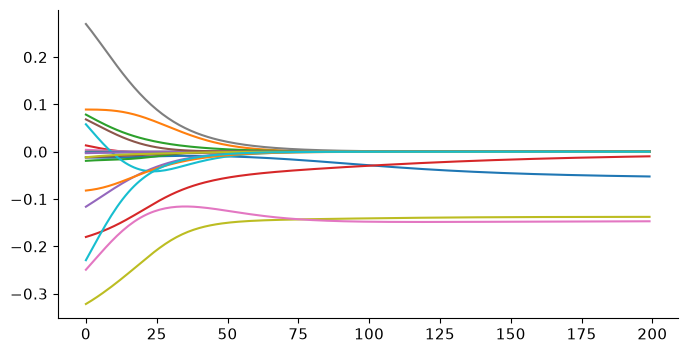

```python
tau = 0.05
niter = 200
x_pro = np.zeros((p, niter))
v = np.random.randn(p)
for it in range(niter):
    f, g = nabla_f(v)
    v -= tau * g
    x_pro[:, it] = v * u_opt(v)
plt.plot(x_pro.T);
```

While the trajectory of ISTA are piecewise smooth, and are not differentiable when crossing 0, the trajectory of this bilevel method can smoothly cross or approach 0.

## Non-convex Pro method: using BFGS

One can show that $f$ is a smooth function. Although it is non-convex, it has no spurious local minima and its saddle points (such as $v=0$) are "ridable" (aka strict saddle), so that trajectory of descent method are not blocked as such saddle points.

```python
from scipy.io import loadmat
from sklearn.preprocessing import StandardScaler

samples = loadmat("nt_toolbox/data/ml-prostate.mat")["A"]
A = samples[:, :-2].copy()
y = samples[:, -2].copy()
n, p = A.shape
print(f"Prostate regression dataset: n={n}, p={p}")
```

```
Prostate regression dataset: n=97, p=8
```

```python
import scipy

if scipy.sparse.issparse(A):
    A = A.toarray()

from sklearn.preprocessing import StandardScaler

A = StandardScaler().fit_transform(A)
y -= y.mean()
```

We select $\lambda$ as a fraction of $\|A^\top y\|_\infty$.

```python
la = 0.1 * norm(A.T @ y, ord=np.inf)
```

Then re-define the function computing $\nabla f$, select the most efficient formula to compute $u^\star(v)$.

```python
def u_opt(v):
    S = A @ np.diag(v**2) @ A.T + la * np.eye(n)
    return v * (A.T @ np.linalg.solve(S, y))


def nabla_f(v):
    u = u_opt(v)
    f = 1 / (2 * la) * norm(A @ (u * v) - y) ** 2 + (norm(u) ** 2 + norm(v) ** 2) / 2
    g = u * (A.T @ (A @ (u * v) - y)) / la + v
    return f, g
```

Denoting $C \triangleq A^\top A \in \mathbb{R}^{p \times p}$ the correlation matrix and $h \triangleq A^\top y \in \mathbb{R}^p$, since $$ \|Ax-y\|^2 = \langle Cx,x \rangle + \langle y,y \rangle - 2 \langle x,h \rangle $$ the Lasso problem only depends on $C$ and $h$. When $n>p$, it is faster to implement the solver in these variables.

```python
C = A.T @ A
ATy = A.T @ y
y2 = y @ y

if scipy.sparse.issparse(C):
    C = C.toarray()


def u_opt_cov(v):
    T = np.outer(v, v) * C + la * np.eye(p)
    return np.linalg.solve(T, v * ATy)


def nabla_f_cov(v):
    u = u_opt(v)
    x = u * v
    E = (C @ x) @ x + y2 - 2 * x @ ATy
    f = 1 / (2 * la) * E + (norm(u) ** 2 + norm(v) ** 2) / 2
    g = u * (C @ x - ATy) / la + v
    return f, g
```

```python
if n < 200 and p < 200:
    v = np.random.randn(p)
    f1, g1 = nabla_f(v)
    f2, g2 = nabla_f_cov(v)
    print(f"Function difference, should be 0: {(f1 - f2):.2e}")
    print(f"Gradient difference, should be 0: {norm(g1 - g2):.2e}")
```

```
Function difference, should be 0: 0.00e+00
Gradient difference, should be 0: 1.06e-15
```

```python
if p < n:
    print("p<n, using covariance mode")
    u_opt = u_opt_cov
    nabla_f = nabla_f_cov
else:
    print("p>n, using full mode")
```

```
p<n, using covariance mode
```

In order to obtain an efficient numerical scheme, one should use a quasi-Newton [L-BFGS](https://en.wikipedia.org/wiki/Broyden%E2%80%93Fletcher%E2%80%93Goldfarb%E2%80%93Shanno_algorithm). The option `maxcor` controls the size of the memory.

```python
# callback to store intermediate results
flist = []
tlist = []
t0 = time.time()


def callback(v):
    f, g = nabla_f(v)
    flist.append(f)
    tlist.append(time.time() - t0)
    return f, g


# run L-BFGS
import scipy.optimize

v0 = np.random.randn(p)
opts = {"gtol": 1e-10, "maxiter": 1000, "maxcor": 10, "ftol": 1e-14, "maxfun": 10000}
result = scipy.optimize.minimize(
    callback, v0, method="L-BFGS-B", jac=True, tol=1e-10, options=opts
)
# retrieve optimal solution
v = result.x
x_pro = v * u_opt(v)
```

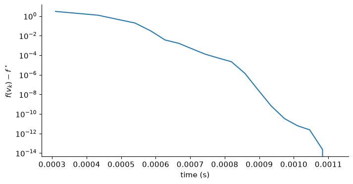

```python
tlist = np.array(tlist)
flist = np.array(flist)
fstar = np.min(flist)
plt.semilogy(tlist, flist - fstar)
plt.xlabel("time (s)")
plt.ylabel(r"$f(v_k) - f^\star$");
```

```
Sparsity: 62 %
```

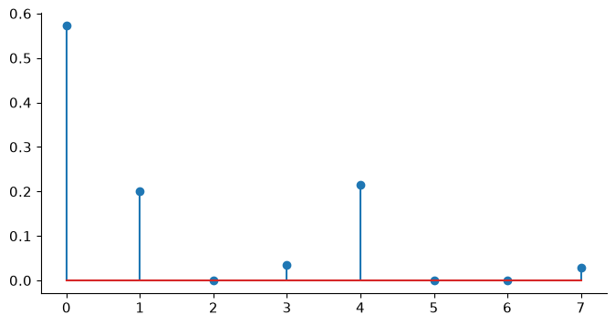

```python
plt.stem(x_pro)
s = np.sum(np.abs(x_pro) > 1e-3)
print(f"Sparsity: {(s / p * 100).astype(int)} %")
```

We compare agains [Celer](https://github.com/mathurinm/celer)'s algorithm. Note that this algorithm is very efficient (more efficient than the bilevel method) for large $\lambda$.

```python
def lasso_func(x):
    return 1 / (2 * la) * norm(A @ x - y) ** 2 + norm(x, 1)
```

```python
import celer
import warnings
from sklearn.exceptions import ConvergenceWarning

# Deliberately stop early to measure the accuracy/time tradeoff.
m = 10
niter_list = np.arange(1, 21, 20 // m)
tlist_celer = np.zeros(m)
flist_celer = np.zeros(m)
dual_gaps = np.zeros(m)
early_stops = 0
for i, niter in enumerate(niter_list):
    model = celer.Lasso(
        alpha=la / n,
        verbose=False,
        fit_intercept=False,
        max_iter=int(niter),
        tol=1e-9,
    )
    t0 = time.time()
    with warnings.catch_warnings(record=True) as notices:
        warnings.simplefilter("always", ConvergenceWarning)
        model.fit(A, y)
    early_stops += any(issubclass(w.category, ConvergenceWarning) for w in notices)
    for notice in notices:
        if not issubclass(notice.category, ConvergenceWarning):
            warnings.warn(str(notice.message), notice.category)
    x_celer = model.coef_.T
    tlist_celer[i] = time.time() - t0
    flist_celer[i] = lasso_func(x_celer)
    dual_gaps[i] = model.dual_gap_
print(
    f"{early_stops}/{m} intentionally truncated runs stopped before the requested tolerance."
)
print(f"Final Celer duality gap: {dual_gaps[-1]:.3g}")
assert np.isfinite(flist_celer).all() and np.isfinite(dual_gaps).all()
```

```
1/10 intentionally truncated runs stopped before the requested tolerance.
Final Celer duality gap: 9.34e-11
```

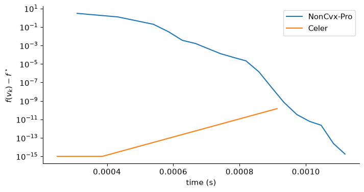

```python
fstar = min(np.min(flist_celer), np.min(flist))
tmax = np.inf
plt.semilogy(
    tlist[tlist < tmax],
    np.maximum(flist[tlist < tmax] - fstar, 1e-15),
    label="NonCvx-Pro",
)
plt.semilogy(tlist_celer, np.maximum(flist_celer - fstar, 1e-15), label="Celer")
plt.legend()
plt.xlabel("time (s)")
plt.ylabel(r"$f(v_k)-f^\star$");
```

## References and further reading

- Stephen Boyd and Lieven Vandenberghe. [Convex Optimization](https://web.stanford.edu/~boyd/cvxbook/). 2004, Cambridge University Press. Convexity, duality, optimality conditions, and interior-point methods.
- Neal Parikh and Stephen Boyd. [Proximal Algorithms](https://web.stanford.edu/~boyd/papers/prox_algs.html). 2014, Foundations and Trends in Optimization 1(3), 127–239. Proximity operators and splitting methods for nonsmooth objectives.
- Amir Beck and Marc Teboulle. [A Fast Iterative Shrinkage-Thresholding Algorithm for Linear Inverse Problems](https://doi.org/10.1137/080716542). 2009, SIAM Journal on Imaging Sciences 2(1), 183–202. Accelerated proximal gradient descent and its convergence rate.
- Antonin Chambolle and Thomas Pock. [A First-Order Primal-Dual Algorithm for Convex Problems with Applications to Imaging](https://doi.org/10.1007/s10851-010-0251-1). 2011, Journal of Mathematical Imaging and Vision 40, 120–145. Primal–dual splitting for total variation and other composite penalties.
- Laurent Condat. [A Primal–Dual Splitting Method for Convex Optimization Involving Lipschitzian, Proximable and Linear Composite Terms](https://doi.org/10.1007/s10957-012-0245-9). 2013, Journal of Optimization Theory and Applications 158, 460–479. Step-size conditions and a general primal–dual framework.